# An Introduction to Mixed-Effect Modeling

Clay Ford

2024-12-18

## Generate data

Let’s generate data that would require a mixed-effect model. Don’t worry too much about the R code here. What’s important to note is the *structure* of the data. We have multiple observations *per mouse* for each region. You’ll also notice that when we generate “angle”, we set mutant mice to have have angles about 20 units higher on average.

```r
# ensure all random data is reproducible
set.seed(7)
# number of mice
n <- 10
# id number of mouse
id <- 1:n
# region
region <- paste0("R", 1:12)
# generate all combinations of id and region
d <- expand.grid(id = id, region = region)
d$id <- factor(d$id)
d$region <- factor(d$region)
# number of samples per id per region
n_i <- sample(1:12, size = n * 12, replace = TRUE)
# expand data frame according to n_i
library(tidyr)
d <- uncount(d, n_i)
# add trt variable. Mice 1-5 are control, mice 6 - 10 are mutant
d$trt <- ifelse(d$id %in% 1:5, "control", "mutant")
# generate angle
e <- rnorm(nrow(d), mean = 0, sd = 5) # within mouse random variation
z <- rnorm(n, mean = 0, sd = 10) # between mouse random variation
d$angle <- (30 + z[d$id]) + (d$trt == "mutant")*20 +
  (d$region == "R2")*45 +
  (d$region == "R3")*60 +
  (d$region == "R4")*1 +
  (d$region == "R5")*45 +
  (d$region == "R6")*90 +
  (d$region == "R7")*120 +
  (d$region == "R8")*45 +
  (d$region == "R9")*120 +
  (d$region == "R10")*45 +
  (d$region == "R11")*90 +
  (d$region == "R12")*60 +
  e
# order data by id and reset row numbers
d <- d[order(d$id),]
rownames(d) <- NULL
# first 12 rows of data
head(d, n = 12)
```

```
##    id region     trt    angle
## 1   1     R1 control 12.14341
## 2   1     R1 control 13.80058
## 3   1     R1 control 16.27658
## 4   1     R1 control 28.70206
## 5   1     R1 control 18.30152
## 6   1     R1 control 16.60983
## 7   1     R1 control 16.73469
## 8   1     R1 control 14.62147
## 9   1     R1 control 12.62507
## 10  1     R1 control 15.03008
## 11  1     R2 control 61.23030
## 12  1     R2 control 57.14395
```

## Visualize the data

Compare control and mutant angle by region.

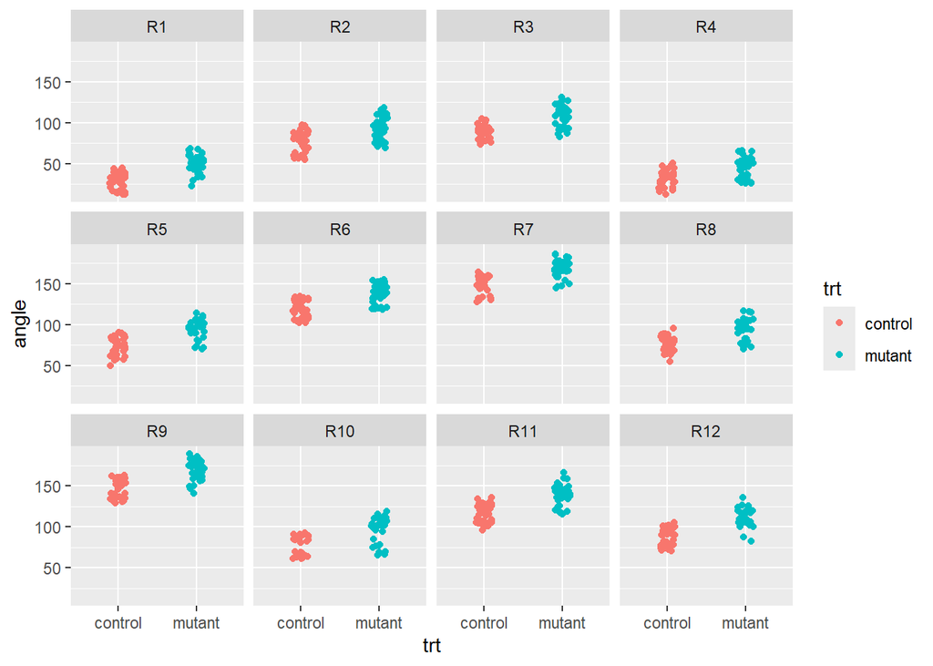

```r
library(ggplot2)
ggplot(d) +
  aes(x = trt, y = angle, color = trt) +
  geom_jitter(height = 0, width = 0.1) +
  facet_wrap(~region)
```

Compare regions by treatment. Notice the variability within mice as well as between mice. There are too many mice to be using colors here, but I think it helps show the variability within each mouse.

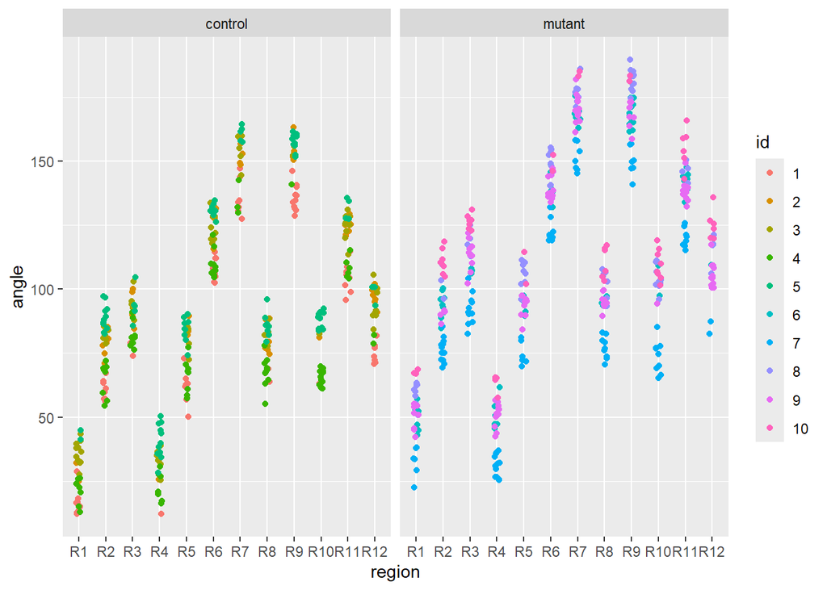

```r
ggplot(d) +
  aes(x = region, y = angle, color = id) +
  geom_jitter(height = 0, width = 0.1) +
  facet_wrap(~trt)
```

## Summary stats

Calculate mean angles by region and trt. Notice mutant is always higher, which is how we simulated the data. In fact, eyeballing the values shows the means between the two treatment groups to differ by about 20.

```r
tapply(d$angle, list(d$region, d$trt), mean)
```

```
##       control    mutant
## R1   27.14998  50.84019
## R2   75.81143  91.84096
## R3   88.17262 109.74498
## R4   32.08946  45.57595
## R5   73.49191  93.93902
## R6  117.46275 137.47093
## R7  148.15314 168.42542
## R8   77.39310  95.14166
## R9  148.64733 169.25768
## R10  76.08697  95.99950
## R11 118.14566 138.87903
## R12  89.22379 111.00149
```

Calculate standard deviation by region and trt. This is fairly constant, just as we simulated the data.

```r
tapply(d$angle, list(d$region, d$trt), sd)
```

```
##       control   mutant
## R1  10.340450 10.91496
## R2  12.160859 13.88580
## R3   8.377962 13.54453
## R4   9.712599 11.89154
## R5  11.557692 12.15290
## R6  10.491266 10.79479
## R7  11.865344 10.30607
## R8   9.159816 11.99433
## R9  11.275020 11.91152
## R10 11.659532 16.14214
## R11 10.853121 11.77691
## R12 10.812055 11.90849
```

Count of observations by mouse and region.

```r
xtabs(~ region + id, data = d)
```

```
##       id
## region  1  2  3  4  5  6  7  8  9 10
##    R1  10  3 12  7  2 10  6  8  8  3
##    R2   8  8  6  8 11 10 12  3  4  8
##    R3   2  6  6 11  5  4 11  6 10  7
##    R4   2  4  6  8 11  8 12  1 11  4
##    R5   9  3  5  8  9  5  6  8  9  2
##    R6  12  5  8 10  8 10 10  8 11  2
##    R7   7  5  6  3  5  9  7  8 12  2
##    R8   2  8  6 10  8  7  9  9  8  6
##    R9  12  6  4  1 11 12  7 12  7  2
##    R10  1  1  1 12 11  2  9 10  1  8
##    R11  9 11  9  6  4 11  8  4 12  6
##    R12  8  8  9  2  3  2  2  5 11  7
```

## Analysis approaches

### 2-way ANOVA: The WRONG approach

Treat observations as independent. Notice the Residuals degrees of freedom is way too high.

```r
library(car)
m0 <- lm(angle ~ trt + region, data = d)
Anova(m0)
```

```
## Anova Table (Type II tests)
##
## Response: angle
##            Sum Sq  Df F value    Pr(>F)
## trt         79879   1  596.71 < 2.2e-16 ***
## region    1174406  11  797.54 < 2.2e-16 ***
## Residuals  109905 821
## ---
## Signif. codes:  0 '***' 0.001 '**' 0.01 '*' 0.05 '.' 0.1 ' ' 1
```

Notice how precise the estimate of trt is with a standard error of 0.8039. That’s too good to be true.

```r
summary(m0)
```

```
##
## Call:
## lm(formula = angle ~ trt + region, data = d)
##
## Residuals:
##     Min      1Q  Median      3Q     Max
## -30.493  -8.740   1.538   8.859  27.456
##
## Coefficients:
##             Estimate Std. Error t value Pr(>|t|)
## (Intercept)  29.2059     1.4513  20.123   <2e-16 ***
## trtmutant    19.6370     0.8039  24.428   <2e-16 ***
## regionR2     44.8942     1.9123  23.476   <2e-16 ***
## regionR3     60.0482     1.9775  30.366   <2e-16 ***
## regionR4     -0.4212     1.9846  -0.212    0.832
## regionR5     44.6657     2.0082  22.242   <2e-16 ***
## regionR6     88.4380     1.8799  47.044   <2e-16 ***
## regionR7    119.3244     2.0091  59.391   <2e-16 ***
## regionR8     47.1783     1.9428  24.284   <2e-16 ***
## regionR9    119.9675     1.9365  61.952   <2e-16 ***
## regionR10    47.0286     2.0811  22.598   <2e-16 ***
## regionR11    89.5016     1.9009  47.083   <2e-16 ***
## regionR12    61.0319     2.0711  29.469   <2e-16 ***
## ---
## Signif. codes:  0 '***' 0.001 '**' 0.01 '*' 0.05 '.' 0.1 ' ' 1
##
## Residual standard error: 11.57 on 821 degrees of freedom
## Multiple R-squared:  0.9203, Adjusted R-squared:  0.9191
## F-statistic: 789.7 on 12 and 821 DF,  p-value: < 2.2e-16
```

### 2-way ANOVA: The old-school approach

Aggregate angle by mouse and region and then run a 2-way ANOVA. Again, don’t worry too much about the R code. Just notice the final data has 120 rows, one observation per mouse per region.

```r
d$angle_mean <- ave(d$angle, d$id, d$region, FUN = mean)
d2 <- d[,c("id", "region", "trt", "angle_mean")]
d2 <- d2[!duplicated(d2),]
head(d2)
```

```
##    id region     trt angle_mean
## 1   1     R1 control   16.48453
## 11  1     R2 control   60.71537
## 19  1     R3 control   76.37301
## 21  1     R4 control   19.01390
## 23  1     R5 control   61.38754
## 32  1     R6 control  107.71647
```

```r
nrow(d2)
```

```
## [1] 120
```

Now do the 2-way ANOVA with the aggregated data. The degrees of freedom looks good.

```r
m1 <- lm(angle_mean ~ trt + region, data = d2)
Anova(m1)
```

```
## Anova Table (Type II tests)
##
## Response: angle_mean
##           Sum Sq  Df F value    Pr(>F)
## trt        12955   1  103.54 < 2.2e-16 ***
## region    167492  11  121.70 < 2.2e-16 ***
## Residuals  13388 107
## ---
## Signif. codes:  0 '***' 0.001 '**' 0.01 '*' 0.05 '.' 0.1 ' ' 1
```

The estimate for trt is good and has a more realistic standard error, but the standard errors for all region coefficients are the same. That’s not realistic.

```r
summary(m1)
```

```
##
## Call:
## lm(formula = angle_mean ~ trt + region, data = d2)
##
## Residuals:
##     Min      1Q  Median      3Q     Max
## -23.794  -8.883   2.343   8.129  16.455
##
## Coefficients:
##             Estimate Std. Error t value Pr(>|t|)
## (Intercept)   30.293      3.682   8.228 4.96e-13 ***
## trtmutant     20.781      2.042  10.176  < 2e-16 ***
## regionR2      44.149      5.002   8.826 2.29e-14 ***
## regionR3      58.998      5.002  11.794  < 2e-16 ***
## regionR4      -1.213      5.002  -0.242    0.809
## regionR5      44.643      5.002   8.924 1.38e-14 ***
## regionR6      88.881      5.002  17.768  < 2e-16 ***
## regionR7     118.307      5.002  23.650  < 2e-16 ***
## regionR8      45.637      5.002   9.123 4.91e-15 ***
## regionR9     118.707      5.002  23.730  < 2e-16 ***
## regionR10     45.806      5.002   9.157 4.12e-15 ***
## regionR11     88.774      5.002  17.747  < 2e-16 ***
## regionR12     57.578      5.002  11.510  < 2e-16 ***
## ---
## Signif. codes:  0 '***' 0.001 '**' 0.01 '*' 0.05 '.' 0.1 ' ' 1
##
## Residual standard error: 11.19 on 107 degrees of freedom
## Multiple R-squared:  0.9309, Adjusted R-squared:  0.9232
## F-statistic: 120.2 on 12 and 107 DF,  p-value: < 2.2e-16
```

### 2-way ANOVA: mixed-effect model approach

Use all the data and specify a *random intercept* for each mouse. That’s what the `(1|id)` syntax does. We’re essentially fitting a separate model to *each mouse*. Notice the test of trt effect is much more modest now, but still “significant”.

```r
library(lmerTest)
m2 <- lmer(angle ~ trt + region + (1|id), data = d)
Anova(m2, test.statistic = "F")
```

```
## Analysis of Deviance Table (Type II Wald F tests with Kenward-Roger df)
##
## Response: angle
##                F Df Df.res  Pr(>F)
## trt       8.1422  1   8.00 0.02137 *
## region 4291.0832 11 813.06 < 2e-16 ***
## ---
## Signif. codes:  0 '***' 0.001 '**' 0.01 '*' 0.05 '.' 0.1 ' ' 1
```

1. `id`: between mice, estimated to be about 11.7
2. `Residual`: within mice, estimated to be about 5

Compare these values to what we used to simulate the variation above.

```r
summary(m2, corr = F)
```

```
## Linear mixed model fit by REML. t-tests use Satterthwaite's method [
## lmerModLmerTest]
## Formula: angle ~ trt + region + (1 | id)
##    Data: d
##
## REML criterion at convergence: 5052.5
##
## Scaled residuals:
##      Min       1Q   Median       3Q      Max
## -3.03149 -0.67567 -0.01745  0.66591  2.86289
##
## Random effects:
##  Groups   Name        Variance Std.Dev.
##  id       (Intercept) 137.19   11.713
##  Residual              24.25    4.924
## Number of obs: 834, groups:  id, 10
##
## Fixed effects:
##             Estimate Std. Error       df t value Pr(>|t|)
## (Intercept)  30.1668     5.2750   8.1913   5.719 0.000408 ***
## trtmutant    21.1611     7.4160   7.9996   2.853 0.021367 *
## regionR2     44.4334     0.8224 813.0788  54.027  < 2e-16 ***
## regionR3     59.5754     0.8501 813.0756  70.084  < 2e-16 ***
## regionR4     -0.4560     0.8552 813.0868  -0.533 0.593985
## regionR5     44.3914     0.8593 813.0386  51.661  < 2e-16 ***
## regionR6     89.3182     0.8026 813.0236 111.281  < 2e-16 ***
## regionR7    118.6060     0.8579 813.0244 138.250  < 2e-16 ***
## regionR8     45.2716     0.8344 813.0693  54.257  < 2e-16 ***
## regionR9    118.5484     0.8315 813.0640 142.566  < 2e-16 ***
## regionR10    44.8701     0.9073 813.1777  49.453  < 2e-16 ***
## regionR11    88.8288     0.8134 813.0434 109.209  < 2e-16 ***
## regionR12    57.7760     0.8889 813.0651  65.000  < 2e-16 ***
## ---
## Signif. codes:  0 '***' 0.001 '**' 0.01 '*' 0.05 '.' 0.1 ' ' 1
```

Above I said we fit a separate model to each mouse. We can see those models by calling `coef()` on the model object. Notice that *each mouse gets their own intercept* but all other coefficients are the same. Hence the reason we call this a *random-intercept model*. This is the correct model, because that is precisely how I simulated the data above! You’ll notice the between mouse variance was added to the intercept to create the “random” intercepts.

```r
coef(m2)
```

```
## $id
##    (Intercept) trtmutant regionR2 regionR3   regionR4 regionR5 regionR6
## 1     17.07787  21.16109 44.43342 59.57542 -0.4560428 44.39145 89.31816
## 2     35.49528  21.16109 44.43342 59.57542 -0.4560428 44.39145 89.31816
## 3     36.06902  21.16109 44.43342 59.57542 -0.4560428 44.39145 89.31816
## 4     21.06847  21.16109 44.43342 59.57542 -0.4560428 44.39145 89.31816
## 5     41.12350  21.16109 44.43342 59.57542 -0.4560428 44.39145 89.31816
## 6     28.96830  21.16109 44.43342 59.57542 -0.4560428 44.39145 89.31816
## 7     10.41599  21.16109 44.43342 59.57542 -0.4560428 44.39145 89.31816
## 8     38.14600  21.16109 44.43342 59.57542 -0.4560428 44.39145 89.31816
## 9     28.95802  21.16109 44.43342 59.57542 -0.4560428 44.39145 89.31816
## 10    44.34583  21.16109 44.43342 59.57542 -0.4560428 44.39145 89.31816
##    regionR7 regionR8 regionR9 regionR10 regionR11 regionR12
## 1   118.606 45.27161 118.5484  44.87011  88.82884  57.77602
## 2   118.606 45.27161 118.5484  44.87011  88.82884  57.77602
## 3   118.606 45.27161 118.5484  44.87011  88.82884  57.77602
## 4   118.606 45.27161 118.5484  44.87011  88.82884  57.77602
## 5   118.606 45.27161 118.5484  44.87011  88.82884  57.77602
## 6   118.606 45.27161 118.5484  44.87011  88.82884  57.77602
## 7   118.606 45.27161 118.5484  44.87011  88.82884  57.77602
## 8   118.606 45.27161 118.5484  44.87011  88.82884  57.77602
## 9   118.606 45.27161 118.5484  44.87011  88.82884  57.77602
## 10  118.606 45.27161 118.5484  44.87011  88.82884  57.77602
##
## attr(,"class")
## [1] "coef.mer"
```

Now we can create post-hoc plots. The difference between control and mutant is the same in each region (about 21) because that’s how we specified our model.

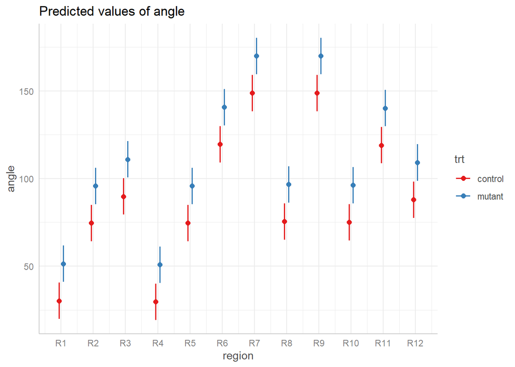

```r
library(ggeffects)
plot(ggpredict(m2, terms = c("region", "trt")))
```

If we thought the effect of trt *varied by region* then we could fit an *interaction*. We do so below by adding `trt:region` to the model. We didn’t simulate this data with interactions, so the interaction is not important.

```r
m3 <- lmer(angle ~ trt + region + trt:region + (1|id), data = d)
Anova(m3, test.statistic = "F")
```

```
## Analysis of Deviance Table (Type II Wald F tests with Kenward-Roger df)
##
## Response: angle
##                    F Df Df.res  Pr(>F)
## trt           8.1097  1   8.00 0.02156 *
## region     4305.1717 11 802.06 < 2e-16 ***
## trt:region    1.2398 11 802.07 0.25602
## ---
## Signif. codes:  0 '***' 0.001 '**' 0.01 '*' 0.05 '.' 0.1 ' ' 1
```

The model summary is much more verbose because of the interaction:

```r
summary(m3, corr = F)
```

```
## Linear mixed model fit by REML. t-tests use Satterthwaite's method [
## lmerModLmerTest]
## Formula: angle ~ trt + region + trt:region + (1 | id)
##    Data: d
##
## REML criterion at convergence: 5012.2
##
## Scaled residuals:
##      Min       1Q   Median       3Q      Max
## -2.72609 -0.68147 -0.01033  0.65661  3.01090
##
## Random effects:
##  Groups   Name        Variance Std.Dev.
##  id       (Intercept) 137.74   11.736
##  Residual              24.17    4.916
## Number of obs: 834, groups:  id, 10
##
## Fixed effects:
##                      Estimate Std. Error        df t value Pr(>|t|)
## (Intercept)          29.65144    5.31792   8.39301   5.576 0.000443 ***
## trtmutant            22.17945    7.51851   8.38333   2.950 0.017506 *
## regionR2             45.65578    1.15525 802.09678  39.520  < 2e-16 ***
## regionR3             58.65510    1.24798 802.10177  47.000  < 2e-16 ***
## regionR4             -0.07122    1.24264 802.12931  -0.057 0.954311
## regionR5             45.21531    1.20375 802.07088  37.562  < 2e-16 ***
## regionR6             89.82184    1.13464 802.04307  79.163  < 2e-16 ***
## regionR7            118.57880    1.28713 802.03731  92.127  < 2e-16 ***
## regionR8             46.32020    1.21233 802.12584  38.208  < 2e-16 ***
## regionR9            118.71904    1.21354 802.12417  97.829  < 2e-16 ***
## regionR10            46.10092    1.32647 802.25756  34.755  < 2e-16 ***
## regionR11            88.91500    1.16250 802.06304  76.486  < 2e-16 ***
## regionR12            59.36710    1.23909 802.04973  47.912  < 2e-16 ***
## trtmutant:regionR2   -2.49499    1.64384 802.08216  -1.518 0.129465
## trtmutant:regionR3    1.55056    1.70375 802.07899   0.910 0.363049
## trtmutant:regionR4   -0.73334    1.71108 802.09364  -0.429 0.668342
## trtmutant:regionR5   -1.64453    1.71782 802.04148  -0.957 0.338687
## trtmutant:regionR6   -0.96385    1.60324 802.02589  -0.601 0.547885
## trtmutant:regionR7   -0.07428    1.72807 802.02432  -0.043 0.965725
## trtmutant:regionR8   -2.00481    1.66918 802.07557  -1.201 0.230078
## trtmutant:regionR9   -0.33940    1.66439 802.07029  -0.204 0.838471
## trtmutant:regionR10  -2.35730    1.81689 802.19004  -1.297 0.194853
## trtmutant:regionR11  -0.17059    1.62464 802.04439  -0.105 0.916401
## trtmutant:regionR12  -3.31690    1.77694 802.06898  -1.867 0.062318 .
## ---
## Signif. codes:  0 '***' 0.001 '**' 0.01 '*' 0.05 '.' 0.1 ' ' 1
```

The post-hoc plot is barely distinguishable from the first plot.

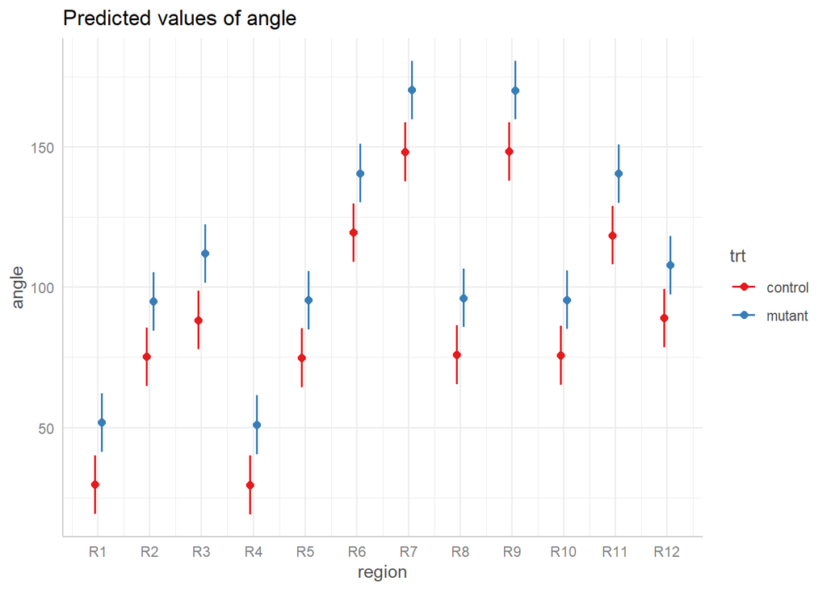

```r
plot(ggpredict(m3, terms = c("region", "trt")))
```